# Code for Randomization Inference and Multiple Hypothesis Testing

## Part 1. Setup

### 1. read in the data, repeating steps from earlier labs

- Use `read.table` to import the data set [PROGRESA.csv](https://www.dropbox.com/s/9hla4hmn84gmbko/PROGRESA.csv?dl=0).
- Read [readme.txt](https://www.dropbox.com/s/ynqfuyliyvxmw8n/readme.txt?dl=0)
- Note `hgc1` is the highest grade completed, and `school` is an indicator for being enrolled in school, so, if they are enrolled in school, then they are enrolled in grade `hgc1`+1.

```r
df_ <- read.csv("https://edward-vytlacil.github.io/Data/PROGRESA.csv",
                    header=TRUE, sep=",") # read csv# Will only use data from wave 4
df_$treat <- df_$progresa1
df_$girl <- df_$sex1
df_$age1 <- ifelse(df_$age1>=6 & df_$age1<=18, df_$age1, NA)
balanced_ids <- intersect(df_[df_$wave==4,"sooind_id"],
                  df_[df_$wave==1 & df_$age1>=6 & df_$age1<=16,"sooind_id"])
df_ <- df_[df_$sooind_id %in% balanced_ids,]
dfPost<-subset(df_, wave==4,select= c(sooloca,sooind_id,age1,hgc1,school,treat,girl,wave))
rm(df_)
```

- Can we do randomization inference using all possible assignments of treatment in this application?
- Impossible.
- Too many permutations to create full matrix of permutations, cannot consider all permutations.

```r
n.0<- length(unique(dfPost$sooloca))
m.0<- length(unique(subset(dfPost,dfPost$treat==1)$sooloca))

n.0
```

```
## [1] 491
```

```r
m.0
```

```
## [1] 308
```

```r
choose(n.0,m.0)
```

```
## [1] 2.452172e+139
```

### randomization inference using ri2 package

- make sure to install and load ri2 package.
- Doing randomization inference not on full set of possible permutations but on random draws from the full 2.452172e+139 possible number of possible permutations.

```r
set.seed(123)

#sims<-3000
sims<-10000  # defining constant, number of simulations to do

#
# defining function for randomization inference
# argument is the data frame, make it easier to do
# on alternative subsets of data
#

f.ri <- function(d){

n.0<- length(unique(d$sooloca))
m.0<- length(unique(subset(d,d$treat==1)$sooloca))

declaration_ra<-declare_ra(N=n.0,m=m.0,clusters=d$sooloca)

ri_out <-  conduct_ri(
     test_function = function(d){abs(mean(d[d$treat==1,]$school) - mean(d[d$treat==0,]$school))},
    declaration = declaration_ra,
    assignment = "treat",
      outcome = "school",
    data = d,
    sims = sims
  )
ri_out}

# full sample

ri.fullsample<- f.ri(dfPost)
summary(ri.fullsample)
```

| term | estimate | two_tailed_p_value |
| --- | --- | --- |
| Custom Test Statistic | 0.03923947 | 9e-04 |

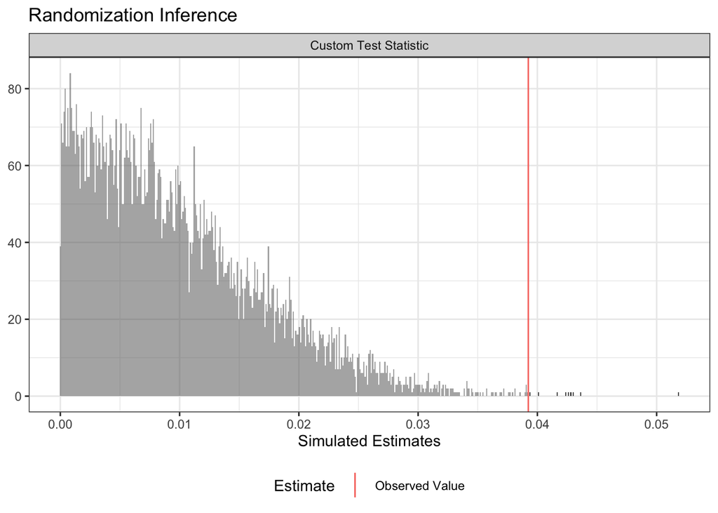

```r
plot(ri.fullsample)
```

```r
# same as above, but now
# separately by boys vs girls

ri.bysex<- by(dfPost, dfPost$girl,f.ri)  # "by" similar to tapply, applying f.ri to dfPost by levels of dfPost$girl
summary(ri.bysex[[1]]) # boys
```

| term | estimate | two_tailed_p_value |
| --- | --- | --- |
| Custom Test Statistic | 0.03280379 | 0.0125 |

```r
summary(ri.bysex[[2]]) # girls
```

| term | estimate | two_tailed_p_value |
| --- | --- | --- |
| Custom Test Statistic | 0.045535 | 0.002 |

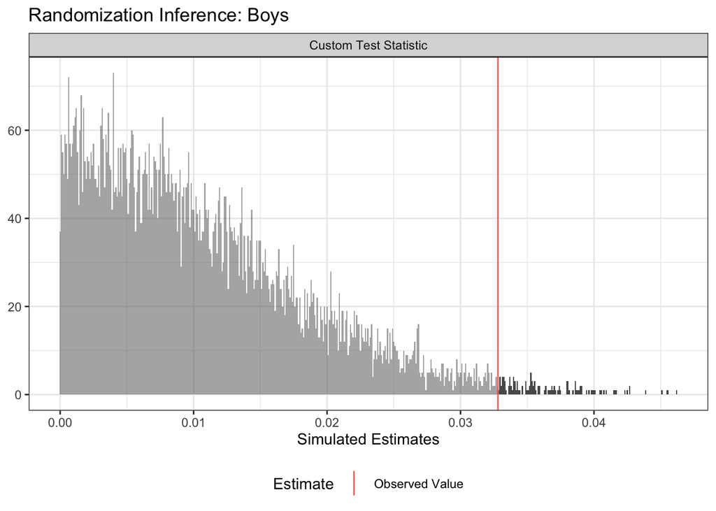

```r
plot(ri.bysex[[1]]) +ggtitle("Randomization Inference: Boys")
```

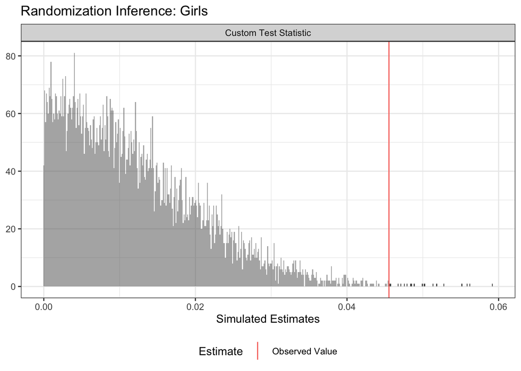

```r
plot(ri.bysex[[2]]) +ggtitle("Randomization Inference: Girls")
```

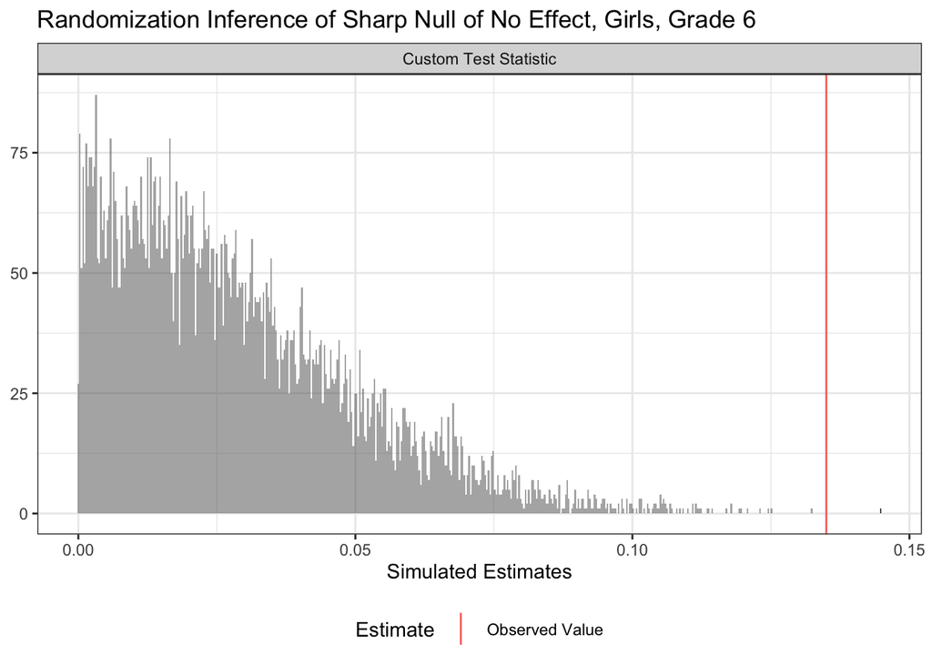

```r
# same as above, but now
# separately by (sex, highest grade completed)
# Use the actual observed hgc1 values rather than hard-coding 1:10.
grade_values <- sort(unique(na.omit(dfPost$hgc1)))

pvalues.boys <- sapply(grade_values, function(g){
  summary(f.ri(subset(dfPost, girl == 0 & hgc1 == g)))$two_tailed_p_value
})

pvalues.girls <- sapply(grade_values, function(g){
  summary(f.ri(subset(dfPost, girl == 1 & hgc1 == g)))$two_tailed_p_value
})

results.p <- data.frame(
  Grade = grade_values,
  `p-value boys` = pvalues.boys,
  `p-value girls` = pvalues.girls,
  check.names = FALSE
)

# example plot: girls, grade 6
ri.girls.grade6 <- f.ri(subset(dfPost, girl == 1 & hgc1 == 6))
plot(ri.girls.grade6) + ggtitle("Randomization Inference of Sharp Null of No Effect, Girls, Grade 6")
```

```r
# Use modelsummary to report a table.
modelsummary::datasummary_df(
  round_df(results.p, 3),
  title = "p-values, inference by sex and grade",
  output = "markdown"
)
```

p-values, inference by sex and grade

| Grade | p-value boys | p-value girls |
| --- | --- | --- |
| 0.00 | 0.35 | 0.61 |
| 1.00 | 0.00 | 0.93 |
| 2.00 | 0.70 | 0.34 |
| 3.00 | 0.00 | 0.03 |
| 4.00 | 0.29 | 0.07 |
| 5.00 | 0.00 | 0.01 |
| 6.00 | 0.01 | 0.00 |
| 7.00 | 0.56 | 0.63 |
| 8.00 | 0.28 | 0.69 |
| 9.00 | 0.26 | 0.66 |

## Multiple hypothesis testing corrections

```r
varlabels  <- grade_values

f.adjust <- function(x,label){
  data.frame(
    Grade = label,
    `No Correction` = x,
    Bonferroni = p.adjust(x, method = "bonferroni"),
    `Holm's` = p.adjust(x, method = "holm"),
    check.names = FALSE
  )
}

modelsummary::datasummary_df(
  round_df(f.adjust(pvalues.boys, varlabels), 3),
  title = "P-Values: Boys, Testing Sharp Null of No Treatment Effect",
  output = "markdown"
)
```

P-Values: Boys, Testing Sharp Null of No Treatment Effect

| Grade | No Correction | Bonferroni | Holm’s |
| --- | --- | --- | --- |
| 0.00 | 0.35 | 1.00 | 1.00 |
| 1.00 | 0.00 | 0.05 | 0.04 |
| 2.00 | 0.70 | 1.00 | 1.00 |
| 3.00 | 0.00 | 0.00 | 0.00 |
| 4.00 | 0.29 | 1.00 | 1.00 |
| 5.00 | 0.00 | 0.02 | 0.01 |
| 6.00 | 0.01 | 0.11 | 0.08 |
| 7.00 | 0.56 | 1.00 | 1.00 |
| 8.00 | 0.28 | 1.00 | 1.00 |
| 9.00 | 0.26 | 1.00 | 1.00 |

```r
modelsummary::datasummary_df(
  round_df(f.adjust(pvalues.girls, varlabels), 3),
  title = "P-Values: Girls, Testing Sharp Null of No Treatment Effect",
  output = "markdown"
)
```

P-Values: Girls, Testing Sharp Null of No Treatment Effect

| Grade | No Correction | Bonferroni | Holm’s |
| --- | --- | --- | --- |
| 0.00 | 0.61 | 1.00 | 1.00 |
| 1.00 | 0.93 | 1.00 | 1.00 |
| 2.00 | 0.34 | 1.00 | 1.00 |
| 3.00 | 0.03 | 0.26 | 0.21 |
| 4.00 | 0.07 | 0.75 | 0.52 |
| 5.00 | 0.01 | 0.07 | 0.06 |
| 6.00 | 0.00 | 0.00 | 0.00 |
| 7.00 | 0.63 | 1.00 | 1.00 |
| 8.00 | 0.69 | 1.00 | 1.00 |
| 9.00 | 0.66 | 1.00 | 1.00 |

## Romano–Wolf stepdown correction

- The earlier `ri2` code computes randomization-inference p-values separately for each hypothesis. That is enough for no correction, Bonferroni, and Holm, because those methods only need the individual p-values.
- Romano–Wolf is different: for each randomization draw, it needs the full vector of test statistics across the family, all computed from the same village-level reassignment.
- So for the final comparison table below, we re-compute all four columns — no correction, Bonferroni, Holm, and Romano–Wolf — from one common bank of village-level random assignments. This makes the final table internally comparable across methods.
- To keep the statistic consistent with the earlier `ri2` code, the statistic here is the same two-sided unstudentized statistic, `abs(mean(Y_1) - mean(Y_0))`, not a studentized t-statistic.

```r
# Build one common bank of village-level treatment assignments.
# We will use the same bank for every grade-specific hypothesis in the family.
make_cluster_draws <- function(d, sims, seed = NULL){
  villages <- sort(unique(d$sooloca))
  n_clusters <- length(villages)

  treat_by_cluster <- tapply(d$treat, d$sooloca, function(x) unique(x)[1])
  W_obs <- as.integer(treat_by_cluster[as.character(villages)])
  m_treat <- sum(W_obs)

  if(!is.null(seed)) set.seed(seed)

  W_perm <- replicate(sims, {
    w <- integer(n_clusters)
    w[sample.int(n_clusters, m_treat)] <- 1L
    w
  })

  list(
    villages = villages,
    W_obs = W_obs,
    W_perm = W_perm,
    sims = sims
  )
}

aggregate_by_cluster <- function(d_sub, villages){
  n_vec <- numeric(length(villages))
  y_vec <- numeric(length(villages))

  if(nrow(d_sub) > 0){
    n_tab <- tapply(!is.na(d_sub$school), d_sub$sooloca, sum)
    y_tab <- tapply(d_sub$school, d_sub$sooloca, sum, na.rm = TRUE)

    n_vec[match(names(n_tab), villages)] <- as.numeric(n_tab)
    y_vec[match(names(y_tab), villages)] <- as.numeric(y_tab)
  }

  list(n_vec = n_vec, y_vec = y_vec)
}

# Match the earlier ri2 test statistic: absolute difference in means.
# This is a two-sided, unstudentized statistic.
abs_diff_in_means <- function(treat_y, treat_n, control_y, control_n){
  out <- abs(treat_y / treat_n - control_y / control_n)
  out[treat_n == 0 | control_n == 0] <- NA_real_
  out
}

stat_from_assignment <- function(y_vec, n_vec, w){
  treat_n <- sum(n_vec * w)
  control_n <- sum(n_vec) - treat_n
  treat_y <- sum(y_vec * w)
  control_y <- sum(y_vec) - treat_y

  abs_diff_in_means(treat_y, treat_n, control_y, control_n)
}

stats_from_permutations <- function(y_vec, n_vec, W_perm){
  treat_n <- colSums(W_perm * n_vec)
  control_n <- sum(n_vec) - treat_n
  treat_y <- colSums(W_perm * y_vec)
  control_y <- sum(y_vec) - treat_y

  abs_diff_in_means(treat_y, treat_n, control_y, control_n)
}

# Romano--Wolf stepdown adjusted p-values based on the common
# permutation matrix of test statistics.
romano_wolf_adjust <- function(T_obs, T_perm){
  K <- length(T_obs)
  ord <- order(T_obs, decreasing = TRUE)
  step_p <- numeric(K)

  for(j in seq_len(K)){
    idx <- ord[j:K]
    max_perm <- apply(T_perm[, idx, drop = FALSE], 1, max, na.rm = TRUE)
    if(all(is.infinite(max_perm))){
      step_p[j] <- NA_real_
    } else {
      valid <- is.finite(max_perm)
      step_p[j] <- (1 + sum(max_perm[valid] >= T_obs[ord[j]])) / (1 + sum(valid))
    }
  }

  adj_ord <- cummax(step_p)
  adj <- numeric(K)
  adj[ord] <- adj_ord
  adj
}

# For one family of hypotheses (here, grades within sex), compute:
# raw permutation p-values, Bonferroni, Holm, and Romano--Wolf.
ri_family_table <- function(d, perm_obj, grades = sort(unique(na.omit(d$hgc1)))){
  K <- length(grades)
  T_obs <- numeric(K)
  T_perm <- matrix(NA_real_, nrow = perm_obj$sims, ncol = K)

  for(j in seq_along(grades)){
    g <- grades[j]
    d_g <- subset(d, hgc1 == g)
    agg <- aggregate_by_cluster(d_g, perm_obj$villages)

    T_obs[j] <- stat_from_assignment(agg$y_vec, agg$n_vec, perm_obj$W_obs)
    T_perm[, j] <- stats_from_permutations(agg$y_vec, agg$n_vec, perm_obj$W_perm)
  }

  # Raw randomization-inference p-values from the same common bank of draws.
  p_raw <- numeric(K)
  for(j in seq_len(K)){
    valid <- !is.na(T_perm[, j])
    p_raw[j] <- (1 + sum(T_perm[valid, j] >= T_obs[j])) / (1 + sum(valid))
  }

  p_rw <- romano_wolf_adjust(T_obs, T_perm)

  data.frame(
    Grade = grades,
    `No Correction` = p_raw,
    Bonferroni = p.adjust(p_raw, method = "bonferroni"),
    `Holm's` = p.adjust(p_raw, method = "holm"),
    `Romano-Wolf` = p_rw,
    check.names = FALSE
  )
}
```

```r
# Use one common bank of village-level random assignments for the final
# comparison table so that differences across methods reflect only the
# correction method, not different simulation draws.
perm_obj <- make_cluster_draws(dfPost, sims = sims, seed = 123)

grade_values_boys  <- sort(unique(na.omit(subset(dfPost, girl == 0)$hgc1)))
grade_values_girls <- sort(unique(na.omit(subset(dfPost, girl == 1)$hgc1)))

rw_boys <- ri_family_table(subset(dfPost, girl == 0), perm_obj = perm_obj, grades = grade_values_boys)
rw_girls <- ri_family_table(subset(dfPost, girl == 1), perm_obj = perm_obj, grades = grade_values_girls)

modelsummary::datasummary_df(
  round_df(rw_boys, 3),
  title = "P-Values: Boys, No Correction vs Bonferroni vs Holm vs Romano-Wolf",
  output = "markdown"
)
```

P-Values: Boys, No Correction vs Bonferroni vs Holm vs Romano-Wolf

| Grade | No Correction | Bonferroni | Holm’s | Romano-Wolf |
| --- | --- | --- | --- | --- |
| 0.00 | 0.38 | 1.00 | 1.00 | 0.79 |
| 1.00 | 0.01 | 0.08 | 0.06 | 0.56 |
| 2.00 | 0.70 | 1.00 | 1.00 | 0.79 |
| 3.00 | 0.00 | 0.00 | 0.00 | 0.26 |
| 4.00 | 0.29 | 1.00 | 1.00 | 0.79 |
| 5.00 | 0.00 | 0.02 | 0.01 | 0.26 |
| 6.00 | 0.01 | 0.13 | 0.09 | 0.14 |
| 7.00 | 0.56 | 1.00 | 1.00 | 0.79 |
| 8.00 | 0.25 | 1.00 | 1.00 | 0.56 |
| 9.00 | 0.27 | 1.00 | 1.00 | 0.30 |

```r
modelsummary::datasummary_df(
  round_df(rw_girls, 3),
  title = "P-Values: Girls, No Correction vs Bonferroni vs Holm vs Romano-Wolf",
  output = "markdown"
)
```

P-Values: Girls, No Correction vs Bonferroni vs Holm vs Romano-Wolf

| Grade | No Correction | Bonferroni | Holm’s | Romano-Wolf |
| --- | --- | --- | --- | --- |
| 0.00 | 0.62 | 1.00 | 1.00 | 0.96 |
| 1.00 | 0.93 | 1.00 | 1.00 | 0.96 |
| 2.00 | 0.35 | 1.00 | 1.00 | 0.96 |
| 3.00 | 0.03 | 0.26 | 0.21 | 0.83 |
| 4.00 | 0.07 | 0.74 | 0.52 | 0.90 |
| 5.00 | 0.01 | 0.09 | 0.08 | 0.42 |
| 6.00 | 0.00 | 0.00 | 0.00 | 0.06 |
| 7.00 | 0.63 | 1.00 | 1.00 | 0.96 |
| 8.00 | 0.69 | 1.00 | 1.00 | 0.96 |
| 9.00 | 0.68 | 1.00 | 1.00 | 0.92 |

## Studentized randomization inference following Bugni, Canay, Shaikh, and Tabord-Meehan

- In the sections above, the test statistic was the absolute value of the child-weighted difference in means.
- We now redo the analysis using the studentized statistic
- $$T_j = |\hat\tau_j| / \hat
  s_j,$$
- where $\hat\tau_j$ is the same child-weighted difference in means, written as a weighted difference in village-level cell means.
- For each sex-grade cell $j$, let $n_{vj}$ be the number of sampled children in village $v$ in that cell and let $\bar Y_{vj}$ be the village-level mean attendance in that cell.
- Then
- $$\hat\tau_j = \frac{\sum_v n_{vj} D_v
  \bar Y_{vj}}{\sum_v n_{vj} D_v} - \frac{\sum_v n_{vj} (1-D_v) \bar
  Y_{vj}}{\sum_v n_{vj} (1-D_v)}.$$
- We take $\hat s_j$ from the village-clustered sandwich variance for the corresponding weighted regression of $\bar Y_{vj}$ on treatment with weights $n_{vj}$, following the size-weighted cluster-level analysis in Bugni, Canay, Shaikh, and Tabord-Meehan. In this one-regressor weighted regression, that sandwich variance simplifies to the formula coded below.
- As above, we use one common bank of village-level random assignments so that the no-correction, Bonferroni, Holm, and Romano–Wolf columns are directly comparable.

```r
# Studentized statistic following the size-weighted cluster-level setup of
# Bugni, Canay, Shaikh, and Tabord-Meehan.
# For a given sex-grade cell j, this keeps the same child-weighted effect
# as above, but now studentizes it using the village-clustered sandwich SE
# from the corresponding weighted regression of village-cell means on treatment.

bcs_stat_from_assignment <- function(y_vec, n_vec, w){
  keep <- n_vec > 0 & !is.na(n_vec)
  n <- n_vec[keep]
  y_sum <- y_vec[keep]
  w <- as.numeric(w[keep])

  if(length(n) == 0 || length(unique(w)) < 2){
    return(c(tau = NA_real_, se = NA_real_, stat = NA_real_))
  }

  N1 <- sum(n * w)
  N0 <- sum(n * (1 - w))
  if(N1 <= 0 || N0 <= 0){
    return(c(tau = NA_real_, se = NA_real_, stat = NA_real_))
  }

  mu1 <- sum(y_sum * w) / N1
  mu0 <- sum(y_sum * (1 - w)) / N0
  tau <- mu1 - mu0

  # In this special case, the village-clustered sandwich variance of the
  # weighted regression coefficient simplifies to the expression below.
  a <- y_sum^2
  b <- n * y_sum
  c <- n^2

  s1a <- sum(w * a)
  s1b <- sum(w * b)
  s1c <- sum(w * c)
  s0a <- sum(a) - s1a
  s0b <- sum(b) - s1b
  s0c <- sum(c) - s1c

  rss1 <- s1a - 2 * mu1 * s1b + mu1^2 * s1c
  rss0 <- s0a - 2 * mu0 * s0b + mu0^2 * s0c
  se2 <- rss1 / (N1^2) + rss0 / (N0^2)

  if(!is.finite(se2) || is.na(se2) || se2 < 0){
    se <- NA_real_
    stat <- NA_real_
  } else if(se2 == 0){
    se <- 0
    stat <- if(abs(tau) > 0) Inf else 0
  } else {
    se <- sqrt(se2)
    stat <- abs(tau) / se
  }

  c(tau = tau, se = se, stat = stat)
}

bcs_stats_from_permutations <- function(y_vec, n_vec, W_perm){
  keep <- n_vec > 0 & !is.na(n_vec)
  n <- n_vec[keep]
  y_sum <- y_vec[keep]
  W_use <- W_perm[keep, , drop = FALSE]

  if(length(n) == 0){
    return(rep(NA_real_, ncol(W_perm)))
  }

  N1 <- colSums(W_use * n)
  N0 <- sum(n) - N1
  Y1 <- colSums(W_use * y_sum)
  Y0 <- sum(y_sum) - Y1

  mu1 <- Y1 / N1
  mu0 <- Y0 / N0
  tau <- mu1 - mu0

  a <- y_sum^2
  b <- n * y_sum
  c <- n^2

  S1a <- colSums(W_use * a)
  S1b <- colSums(W_use * b)
  S1c <- colSums(W_use * c)
  S0a <- sum(a) - S1a
  S0b <- sum(b) - S1b
  S0c <- sum(c) - S1c

  rss1 <- S1a - 2 * mu1 * S1b + mu1^2 * S1c
  rss0 <- S0a - 2 * mu0 * S0b + mu0^2 * S0c
  se2 <- rss1 / (N1^2) + rss0 / (N0^2)

  stat <- rep(NA_real_, length(se2))
  bad <- !is.finite(se2) | is.na(se2) | se2 < 0 | N1 <= 0 | N0 <= 0
  zero_se <- !bad & se2 == 0
  good <- !bad & se2 > 0

  stat[good] <- abs(tau[good]) / sqrt(se2[good])
  stat[zero_se] <- ifelse(abs(tau[zero_se]) > 0, Inf, 0)
  stat
}

ri_family_table_studentized <- function(d, perm_obj, grades = sort(unique(na.omit(d$hgc1)))){
  K <- length(grades)
  T_obs <- numeric(K)
  T_perm <- matrix(NA_real_, nrow = perm_obj$sims, ncol = K)

  for(j in seq_along(grades)){
    g <- grades[j]
    d_g <- subset(d, hgc1 == g)
    agg <- aggregate_by_cluster(d_g, perm_obj$villages)

    obs_out <- bcs_stat_from_assignment(agg$y_vec, agg$n_vec, perm_obj$W_obs)
    T_obs[j] <- obs_out["stat"]
    T_perm[, j] <- bcs_stats_from_permutations(agg$y_vec, agg$n_vec, perm_obj$W_perm)
  }

  p_raw <- numeric(K)
  for(j in seq_len(K)){
    valid <- is.finite(T_perm[, j])
    if(!is.finite(T_obs[j])){
      p_raw[j] <- NA_real_
    } else {
      p_raw[j] <- (1 + sum(T_perm[valid, j] >= T_obs[j])) / (1 + sum(valid))
    }
  }

  p_rw <- romano_wolf_adjust(T_obs, T_perm)

  data.frame(
    Grade = grades,
    `No Correction` = p_raw,
    Bonferroni = p.adjust(p_raw, method = "bonferroni"),
    `Holm's` = p.adjust(p_raw, method = "holm"),
    `Romano-Wolf` = p_rw,
    check.names = FALSE
  )
}
```

```r
student_boys <- ri_family_table_studentized(
  subset(dfPost, girl == 0),
  perm_obj = perm_obj,
  grades = grade_values_boys
)
student_girls <- ri_family_table_studentized(
  subset(dfPost, girl == 1),
  perm_obj = perm_obj,
  grades = grade_values_girls
)

student_results <- merge(
  student_boys[, c("Grade", "No Correction")],
  student_girls[, c("Grade", "No Correction")],
  by = "Grade",
  all = TRUE,
  suffixes = c(" boys", " girls")
)

names(student_results) <- c("Grade", "p-value boys", "p-value girls")

modelsummary::datasummary_df(
  round_df(student_results, 3),
  title = "Studentized p-values, inference by sex and grade",
  output = "markdown"
)
```

Studentized p-values, inference by sex and grade

| Grade | p-value boys | p-value girls |
| --- | --- | --- |
| 0.00 | 0.38 | 0.63 |
| 1.00 | 0.02 | 0.92 |
| 2.00 | 0.69 | 0.35 |
| 3.00 | 0.00 | 0.04 |
| 4.00 | 0.32 | 0.10 |
| 5.00 | 0.00 | 0.01 |
| 6.00 | 0.01 | 0.00 |
| 7.00 | 0.56 | 0.61 |
| 8.00 | 0.26 | 0.69 |
| 9.00 | 0.26 | 0.68 |

```r
modelsummary::datasummary_df(
  round_df(student_boys, 3),
  title = "Studentized P-Values: Boys, No Correction vs Bonferroni vs Holm vs Romano-Wolf",
  output = "markdown"
)
```

Studentized P-Values: Boys, No Correction vs Bonferroni vs Holm vs Romano-Wolf

| Grade | No Correction | Bonferroni | Holm’s | Romano-Wolf |
| --- | --- | --- | --- | --- |
| 0.00 | 0.38 | 1.00 | 1.00 | 0.83 |
| 1.00 | 0.02 | 0.16 | 0.12 | 0.16 |
| 2.00 | 0.69 | 1.00 | 1.00 | 0.83 |
| 3.00 | 0.00 | 0.01 | 0.01 | 0.01 |
| 4.00 | 0.32 | 1.00 | 1.00 | 0.83 |
| 5.00 | 0.00 | 0.04 | 0.04 | 0.04 |
| 6.00 | 0.01 | 0.15 | 0.12 | 0.13 |
| 7.00 | 0.56 | 1.00 | 1.00 | 0.83 |
| 8.00 | 0.26 | 1.00 | 1.00 | 0.83 |
| 9.00 | 0.26 | 1.00 | 1.00 | 0.83 |

```r
modelsummary::datasummary_df(
  round_df(student_girls, 3),
  title = "Studentized P-Values: Girls, No Correction vs Bonferroni vs Holm vs Romano-Wolf",
  output = "markdown"
)
```

Studentized P-Values: Girls, No Correction vs Bonferroni vs Holm vs Romano-Wolf

| Grade | No Correction | Bonferroni | Holm’s | Romano-Wolf |
| --- | --- | --- | --- | --- |
| 0.00 | 0.63 | 1.00 | 1.00 | 0.99 |
| 1.00 | 0.92 | 1.00 | 1.00 | 0.99 |
| 2.00 | 0.35 | 1.00 | 1.00 | 0.92 |
| 3.00 | 0.04 | 0.44 | 0.35 | 0.31 |
| 4.00 | 0.10 | 0.98 | 0.68 | 0.55 |
| 5.00 | 0.01 | 0.15 | 0.14 | 0.13 |
| 6.00 | 0.00 | 0.00 | 0.00 | 0.00 |
| 7.00 | 0.61 | 1.00 | 1.00 | 0.99 |
| 8.00 | 0.69 | 1.00 | 1.00 | 0.99 |
| 9.00 | 0.68 | 1.00 | 1.00 | 0.99 |